# Assignment-1

Evan_Blosser

2023-07-12

```r
# packages
library(ggplot2)
# Functions
# https://www.statology.org/mode-in-r/
find_mode <- function(x) {
  u <- unique(x)
  tab <- tabulate(match(x, u))
  u[tab == max(tab)]
}
```

### Total Questions Answered: 15/15

# Question 1

- There is a total of 4 assignments that are 5% each, with a total value of 20%
- Labratories are a total of 10%
- In Class Quizzes are worth 10%
- The Chapter Quizzes found on CANVAS are worth 10%
- The Project is worth a total of 10%
- The Mid -Term Exam is worth 10%
- The Final is worth 30%
- The Grading Scale is as follows:(No Curving)
  - A 100% - 90%
  - B 89% - 80%
  - C 79% - 60%
  - D 59% - 50%
  - F <50%

# Question 2

```r
ddt <- read.csv(file = "DDT.csv")
head(ddt)
```

```
##   RIVER MILE  SPECIES LENGTH WEIGHT DDT
## 1   FCM    5 CCATFISH   42.5    732  10
## 2   FCM    5 CCATFISH   44.0    795  16
## 3   FCM    5 CCATFISH   41.5    547  23
## 4   FCM    5 CCATFISH   39.0    465  21
## 5   FCM    5 CCATFISH   50.5   1252  50
## 6   FCM    5 CCATFISH   52.0   1255 150
```

```r
miletab <- ddt$MILE
summary(miletab)
```

```
##    Min. 1st Qu.  Median    Mean 3rd Qu.    Max.
##     1.0   283.8   300.0   268.6   320.0   345.0
```

```r
miletab
```

```
##   [1]   5   5   5   5   5   5   3   3   3   3   3   3   1   1   1   1   1   1
##  [19] 275 275 275 275 275 275 280 280 280 280 280 280 280 280 280 280 280 280
##  [37] 285 285 285 285 285 285 285 285 285 285 285 285 290 290 290 290 290 290
##  [55] 290 290 290 290 290 290 295 295 295 295 295 295 300 300 300 300 300 300
##  [73] 300 300 300 300 300 300 305 305 305 305 305 305 310 310 310 310 310 310
##  [91] 310 310 310 310 310 310 315 315 315 315 315 315 320 320 320 320 320 320
## [109] 320 320 320 320 320 320 325 325 325 325 325 325 330 330 330 330 330 330
## [127] 330 330 340 340 340 340 340 340 340 340 340 340 345 345 345 345 345 345
```

## a

```r
m=with(ddt, as.numeric(factor(MILE)))
length(unique(m))
```

```
## [1] 17
```

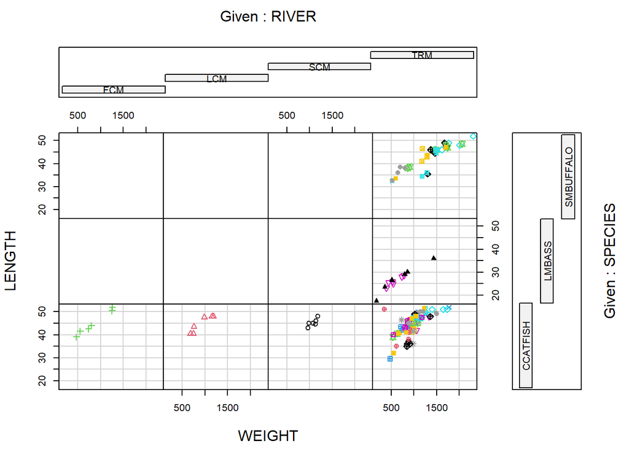

```r
colm=c(m)
coplot(LENGTH~WEIGHT|RIVER*SPECIES,data=ddt,pch=colm, col=colm)
```

## b

The lower left three show **CCATFISH** within the **RIVERS**: **FCM**, **LCM**, **SCM**. The plots show the Varying **MILE** variable by color and shape of each data point. The x-axis shows that most of the **CCATFISH** are within roughly $500$ to $1500$; with an outlier (below $500$) of this being found in **FCM**. This outlier, or lighter **CCATFISH** is also the smallest in **LENGTH** as can be seen on the y-axis. One observation is that **FCM** also had the greatest **LENGTH** above $50$

## c

The given line of code, #A, sets ‘m’ to be a numeric vector of **MILE** found within ddt

## d

The given line of code, #B, asks for the length of the unique elements of m

## e

These plots are empty as there are no **LMBASS** or **SMBUFFALO** within the **RIVERS**: **FCM**, **LCM**, **SCM**.

## f

As shown below the mean value is $45$.

```r
answer2f <- subset(ddt,RIVER=="FCM" & SPECIES=="CCATFISH",)
Answer2fddt <- answer2f$DDT
mean(Answer2fddt)
```

```
## [1] 45
```

```r
summary(answer2f)
```

```
##     RIVER                MILE     SPECIES              LENGTH
##  Length:6           Min.   :5   Length:6           Min.   :39.00
##  Class :character   1st Qu.:5   Class :character   1st Qu.:41.75
##  Mode  :character   Median :5   Mode  :character   Median :43.25
##                     Mean   :5                      Mean   :44.92
##                     3rd Qu.:5                      3rd Qu.:48.88
##                     Max.   :5                      Max.   :52.00
##      WEIGHT            DDT
##  Min.   : 465.0   Min.   : 10.00
##  1st Qu.: 593.2   1st Qu.: 17.25
##  Median : 763.5   Median : 22.00
##  Mean   : 841.0   Mean   : 45.00
##  3rd Qu.:1137.8   3rd Qu.: 43.25
##  Max.   :1255.0   Max.   :150.00
```

# Question 3

classify the following variables as qualitative or quantitative

## a

Length of maximum span (in ft.): quantitative

## b

Number of vehicle lanes: quantitative

## c

Toll bridge (Yes or No): qualitative

## d

Average daily traffic: quantitative

## e

Condition of deck (good, fair, or poor): qualitative

## f

Bypass or detour length (miles): quantitative

## g

Route type (Interstate, US, etc…): qualitative

# Question 4

## a

There is **simple random sampling**; as well as **stratified random sampling**, **cluster sampling**, **systematic sampling**.

## b

- simple random sampling
  - Is a method of taking samples of an **n** size in such a way that each sample has the same probability of selection. this is usually done with simple randomizing programs.
- stratified random sampling
  - Is a method of separating the population, given at least two or more groups of units, into what are known as **strata**. These **strata** for example can be used in experiments to stratify parameters of an experiment such as posted speed limits on vehicle travel time surveys.
- cluster sampling
  - This method uses **natrual groupings** or clusters of experimental units for sampling a population
- systematic sampling
  - This method uses a systematic approach, such as defining a rule of selecting every$k^{th}$ experimental unit from a list of all units.

# Question 5

```r
mtbe=read.csv("MTBE.csv", header=TRUE)
head(mtbe)
```

```
##     pH SpConduct DissOxy RoadsPct IndPct UrbanPct DevPct WellClass Aquifier
## 1 7.87     290.0    0.58     1.34      0    17.77  17.77   Private  Bedrock
## 2 8.63     225.9    0.84     0.72      0    10.43  10.43   Private  Bedrock
## 3 7.11     157.4    8.37     1.92      0    29.62  50.01   Private  Bedrock
## 4 7.98     723.6    0.41     2.76      0    41.65  41.65   Private  Bedrock
## 5 7.88     148.7    1.44     3.51      0    51.21  51.21   Private  Bedrock
## 6 8.36     198.2    0.18     1.48      0    22.49  29.19   Private  Bedrock
##     Depth SafeYld Distance MTBE.Detect MTBE.Level HouseDen PopDen
## 1  60.960      NA  2386.29 Below Limit        0.2   131.16  43.19
## 2  36.576      NA  3667.69 Below Limit        0.2    47.69  24.52
## 3 152.400      NA  2324.15 Below Limit        0.2    85.16  33.32
## 4      NA      NA   788.88 Below Limit        0.2   134.77  46.61
## 5  91.440      NA  1337.88 Below Limit        0.2   198.54  78.58
## 6 115.824      NA  2396.74 Below Limit        0.2   206.73  59.47
```

```r
# rows and columns
dim(mtbe)
```

```
## [1] 223  16
```

```r
# random indices
```

The 5 chosen wells are as follows:

```r
Random_mtbe=sample(1:223,5,replace=FALSE)
mtbe[Random_mtbe,]
```

```
##       pH SpConduct DissOxy RoadsPct IndPct UrbanPct DevPct WellClass Aquifier
## 63  5.62     883.7    3.13     3.07   1.92    44.01  50.34   Private  Bedrock
## 175 7.70     441.0    1.84     1.42   0.00    26.59  31.87    Public  Bedrock
## 135 7.22     286.5    0.60     3.28   0.00    40.78  40.78    Public  Bedrock
## 69  7.12     180.8    4.59     1.76   0.00    28.22  28.22   Private  Bedrock
## 76  8.16     161.9    0.40     2.98   0.00    39.37  39.37   Private  Bedrock
##        Depth   SafeYld Distance MTBE.Detect MTBE.Level HouseDen PopDen
## 63        NA        NA  1319.92      Detect       0.34   335.00 100.24
## 175  91.4400  37.85011  3084.46      Detect       0.72   160.71  79.86
## 135  45.7200 113.55034   367.52 Below Limit       0.20   117.22   0.00
## 69  174.9552        NA  1849.10 Below Limit       0.20    39.92  12.22
## 76        NA        NA  1351.95 Below Limit       0.20    54.85  19.51
```

## a

### i

```r
mtbeo=na.omit(mtbe)
head(mtbeo)
```

```
##       pH SpConduct DissOxy RoadsPct IndPct UrbanPct DevPct WellClass  Aquifier
## 104 7.43     663.2    0.56     2.26   0.00    27.42  27.42    Public Unconsoli
## 105 7.76     919.3    6.63    10.62  22.41    72.02  72.71    Public Unconsoli
## 106 7.01     409.9    5.94     1.58   0.84    20.88  20.88    Public Unconsoli
## 107 6.55     248.6    7.07     2.09   1.34    40.59  49.97    Public Unconsoli
## 108 7.91     223.0   10.60     4.10   6.54    43.08  43.08    Public Unconsoli
## 109 7.51     428.5    7.94     1.95   0.00    35.42  51.90    Public Unconsoli
##       Depth   SafeYld Distance MTBE.Detect MTBE.Level HouseDen PopDen
## 104 15.2400 1514.0045  1142.56      Detect       0.25    17.71   7.38
## 105 15.2400 1324.7540   274.61 Below Limit       0.20   132.22  46.20
## 106 19.2024 1052.2332   775.40 Below Limit       0.20    92.24  33.89
## 107 15.2400  946.2528   685.17 Below Limit       0.20   375.34 114.84
## 108 14.6304  946.2528  3192.79 Below Limit       0.20    77.01  34.23
## 109 24.9936  946.2528  2440.35      Detect       1.06   146.11  52.56
```

### ii

The standard deviation of **Bedrock** Aquifier’s **DEPTH** is $\approx 56.4536$

```r
depth=mtbeo[mtbeo$Aquifier=="Bedrock",]$Depth
sd(depth)
```

```
## [1] 56.45357
```

# Question 6

```r
earthquake <- read.csv(file='EARTHQUAKE.csv')
head(earthquake)
```

```
##   YEAR MONTH DAY HOUR MINUTE MAGNITUDE
## 1 1994     1  17   12     30       6.7
## 2 1994     1  17   12     31       5.5
## 3 1994     1  17   12     32       3.3
## 4 1994     1  17   12     34       4.2
## 5 1994     1  17   12     36       3.8
## 6 1994     1  17   12     37       3.7
```

```r
dim(earthquake)
```

```
## [1] 2929    6
```

The following 30 aftershocks were chosen:

```r
Random_earth = sample(1:2929,30,replace=FALSE)
earthquake[Random_earth,]
```

```
##      YEAR MONTH DAY HOUR MINUTE MAGNITUDE
## 1734 1994     1  25   21      4       1.8
## 996  1994     1  21   19     27       2.8
## 1942 1994     1  27    3     15       1.6
## 2622 1994     2   3    8     56       1.8
## 1604 1994     1  25    2      6       2.8
## 2523 1994     2   2   12     20       2.0
## 203  1994     1  18    1     31       2.6
## 128  1994     1  17   19     14       2.7
## 185  1994     1  17   23     44       3.1
## 2854 1994     2   5   11     47       2.3
## 2889 1994     2   5   18     57       1.1
## 2416 1994     2   1    9     23       1.9
## 504  1994     1  19   18     39       2.5
## 1326 1994     1  23   11      5       2.0
```

[output cut: 16 more lines]

## a

### i

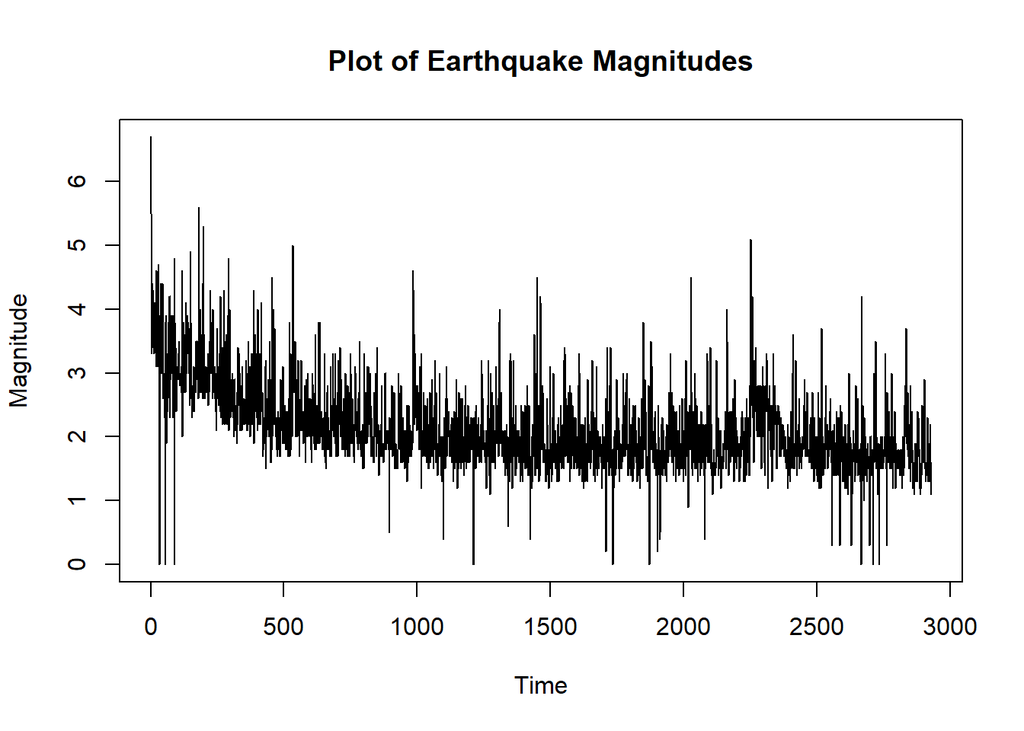

```r
plot(ts(earthquake$MAG),main="Plot of Earthquake Magnitudes",xlab="Time",ylab="Magnitude")
```

### ii

The median of the variable **MAGNITUDE** is **2**.

```r
median(earthquake$MAGNITUDE)
```

```
## [1] 2
```

# Question 7

## a

This would be **Cluster Sampling** colleciton method.

## b

The population is the **Tennessee River**.

## c

The **Capture Location** and **Species** as stated in the text. However within capture location the **River** is the main qualitative variable, while the **Mile** is quantitative.

# Question 8

## a

The graph used on **Page 26** is a **Bar Graph**.

## b

The variable measured was **Robot Mode of Transportation** to see if they had **Legs**, **Wheels**, **None**, or **Both**.

## c

The graph on **Page 26** shows that robots with **Legs** are the current social design; as there were **63** of the **106** robots with **Legs**.

## d

The class relative frequency of **Robots with Legs Only** is: $\approx 0.59434$

```r
63/106
```

```
## [1] 0.5943396
```

The class relative frequency of **Robots with Wheels Only** is: $\approx 0.18868$

```r
20/106
```

```
## [1] 0.1886792
```

The class relative frequency of **Robots with None** is:$\approx 0.14151$

```r
15/106
```

```
## [1] 0.1415094
```

The class relative frequency of **Robots with Both** is: $\approx 0.07547$

```r
8/106
```

```
## [1] 0.0754717
```